# MPG Analysis for Manual and Automatic Transmissions

Jesica Scott

February 3, 2019

# Executive Summary

The data for miles per gallon (MPG) for both manual and automatic transmissions will be analyzed via the “mtcars” data set. The main questions that we will look to answer are whether a manual or automatic transmission is better (has a higher number of MPG) and to quantify the difference in MPG between the two.

Ultimately, we find that a multivariate linear regression model with confounding variables provides the best insight in understanding the differences in MPG for manual and automatic transmissions.

# Exploratory Analysis

First let’s get familiar with the “mtcars” data.

```r
library(datasets)
data(mtcars)
head(mtcars)
```

|  | mpg | cyl | disp | hp | drat | wt | qsec | vs | am | gear | carb |
| --- | --- | --- | --- | --- | --- | --- | --- | --- | --- | --- | --- |
| Mazda RX4 | 21.0 | 6 | 160 | 110 | 3.90 | 2.620 | 16.46 | 0 | 1 | 4 | 4 |
| Mazda RX4 Wag | 21.0 | 6 | 160 | 110 | 3.90 | 2.875 | 17.02 | 0 | 1 | 4 | 4 |
| Datsun 710 | 22.8 | 4 | 108 | 93 | 3.85 | 2.320 | 18.61 | 1 | 1 | 4 | 1 |
| Hornet 4 Drive | 21.4 | 6 | 258 | 110 | 3.08 | 3.215 | 19.44 | 1 | 0 | 3 | 1 |
| Hornet Sportabout | 18.7 | 8 | 360 | 175 | 3.15 | 3.440 | 17.02 | 0 | 0 | 3 | 2 |
| Valiant | 18.1 | 6 | 225 | 105 | 2.76 | 3.460 | 20.22 | 1 | 0 | 3 | 1 |

```r
dim(mtcars)
```

```
## [1] 32 11
```

```r
summary(mtcars)
```

```
##       mpg             cyl             disp             hp
##  Min.   :10.40   Min.   :4.000   Min.   : 71.1   Min.   : 52.0
##  1st Qu.:15.43   1st Qu.:4.000   1st Qu.:120.8   1st Qu.: 96.5
##  Median :19.20   Median :6.000   Median :196.3   Median :123.0
##  Mean   :20.09   Mean   :6.188   Mean   :230.7   Mean   :146.7
##  3rd Qu.:22.80   3rd Qu.:8.000   3rd Qu.:326.0   3rd Qu.:180.0
##  Max.   :33.90   Max.   :8.000   Max.   :472.0   Max.   :335.0
##       drat             wt             qsec             vs
##  Min.   :2.760   Min.   :1.513   Min.   :14.50   Min.   :0.0000
##  1st Qu.:3.080   1st Qu.:2.581   1st Qu.:16.89   1st Qu.:0.0000
##  Median :3.695   Median :3.325   Median :17.71   Median :0.0000
##  Mean   :3.597   Mean   :3.217   Mean   :17.85   Mean   :0.4375
##  3rd Qu.:3.920   3rd Qu.:3.610   3rd Qu.:18.90   3rd Qu.:1.0000
##  Max.   :4.930   Max.   :5.424   Max.   :22.90   Max.   :1.0000
##        am              gear            carb
##  Min.   :0.0000   Min.   :3.000   Min.   :1.000
##  1st Qu.:0.0000   1st Qu.:3.000   1st Qu.:2.000
##  Median :0.0000   Median :4.000   Median :2.000
##  Mean   :0.4062   Mean   :3.688   Mean   :2.812
##  3rd Qu.:1.0000   3rd Qu.:4.000   3rd Qu.:4.000
##  Max.   :1.0000   Max.   :5.000   Max.   :8.000
```

# Testing the Hypothesis

```r
Test<-t.test(mtcars$mpg~mtcars$am)
Test$p.value
```

```
## [1] 0.001373638
```

Since the p-value is approximately 0.001373, we reject our null hypothesis.

```r
Test$estimate
```

```
## mean in group 0 mean in group 1
##        17.14737        24.39231
```

This shows the mean values for each group. Now we must convert them to factors.

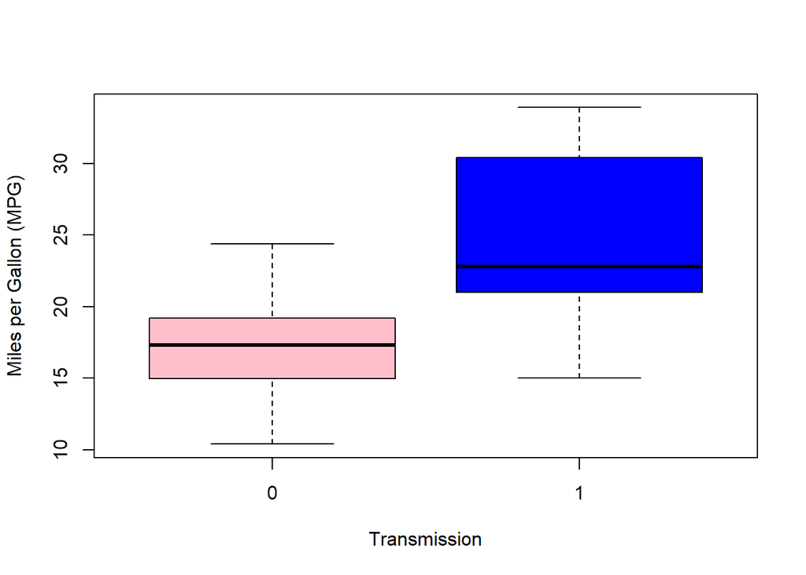

```r
mtcars$am<-as.factor(mtcars$am)
mtcars$vs<-as.factor(mtcars$vs)
boxplot(mpg~am,
        data=mtcars,
        ylab="Miles per Gallon (MPG)",
        xlab="Transmission",
        col=(c("pink","blue")))
```

# Regression Analysis

First we will perform a single linear regression (SLR) fit.

```r
SLR<-lm(mpg~factor(am),data=mtcars)
summary(SLR)
```

```
##
## Call:
## lm(formula = mpg ~ factor(am), data = mtcars)
##
## Residuals:
##     Min      1Q  Median      3Q     Max
## -9.3923 -3.0923 -0.2974  3.2439  9.5077
##
## Coefficients:
##             Estimate Std. Error t value Pr(>|t|)
## (Intercept)   17.147      1.125  15.247 1.13e-15 ***
## factor(am)1    7.245      1.764   4.106 0.000285 ***
## ---
## Signif. codes:  0 '***' 0.001 '**' 0.01 '*' 0.05 '.' 0.1 ' ' 1
##
## Residual standard error: 4.902 on 30 degrees of freedom
## Multiple R-squared:  0.3598, Adjusted R-squared:  0.3385
## F-statistic: 16.86 on 1 and 30 DF,  p-value: 0.000285
```

Since only 33.8% of the regression variance (R^2) can be explained by our model, we will also look at fitting a multivariate linear regression (MLR) model.

```r
MLR<-lm(mpg~.,data=mtcars)
summary(MLR)
```

```
##
## Call:
## lm(formula = mpg ~ ., data = mtcars)
##
## Residuals:
##     Min      1Q  Median      3Q     Max
## -3.4506 -1.6044 -0.1196  1.2193  4.6271
##
## Coefficients:
##             Estimate Std. Error t value Pr(>|t|)
## (Intercept) 12.30337   18.71788   0.657   0.5181
## cyl         -0.11144    1.04502  -0.107   0.9161
## disp         0.01334    0.01786   0.747   0.4635
## hp          -0.02148    0.02177  -0.987   0.3350
## drat         0.78711    1.63537   0.481   0.6353
## wt          -3.71530    1.89441  -1.961   0.0633 .
## qsec         0.82104    0.73084   1.123   0.2739
## vs1          0.31776    2.10451   0.151   0.8814
## am1          2.52023    2.05665   1.225   0.2340
## gear         0.65541    1.49326   0.439   0.6652
## carb        -0.19942    0.82875  -0.241   0.8122
## ---
## Signif. codes:  0 '***' 0.001 '**' 0.01 '*' 0.05 '.' 0.1 ' ' 1
##
## Residual standard error: 2.65 on 21 degrees of freedom
## Multiple R-squared:  0.869,  Adjusted R-squared:  0.8066
## F-statistic: 13.93 on 10 and 21 DF,  p-value: 3.793e-07
```

Where the value for R^2 is 80.66% but let’s look at the correlation.

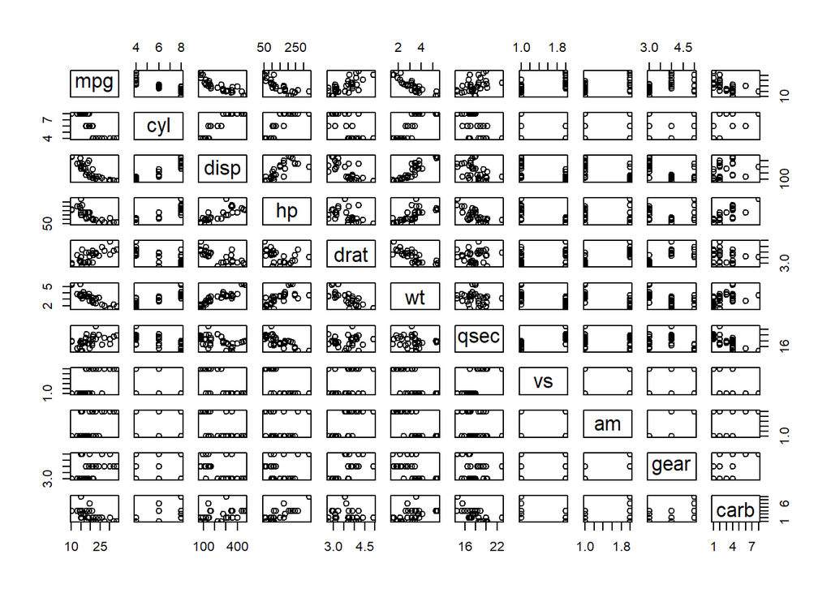

```r
pairs(mpg~.,data=mtcars)
```

This reveals a correlation with cyl, wt, hp, and disp and so we will include them in an additionally adjusted MLR model.

```r
MLRadjusted<-lm(mpg~wt+hp+disp+cyl+am,data=mtcars)
summary(MLRadjusted)
```

```
##
## Call:
## lm(formula = mpg ~ wt + hp + disp + cyl + am, data = mtcars)
##
## Residuals:
##     Min      1Q  Median      3Q     Max
## -3.5952 -1.5864 -0.7157  1.2821  5.5725
##
## Coefficients:
##             Estimate Std. Error t value Pr(>|t|)
## (Intercept) 38.20280    3.66910  10.412 9.08e-11 ***
## wt          -3.30262    1.13364  -2.913  0.00726 **
## hp          -0.02796    0.01392  -2.008  0.05510 .
## disp         0.01226    0.01171   1.047  0.30472
## cyl         -1.10638    0.67636  -1.636  0.11393
## am1          1.55649    1.44054   1.080  0.28984
## ---
## Signif. codes:  0 '***' 0.001 '**' 0.01 '*' 0.05 '.' 0.1 ' ' 1
##
## Residual standard error: 2.505 on 26 degrees of freedom
## Multiple R-squared:  0.8551, Adjusted R-squared:  0.8273
## F-statistic:  30.7 on 5 and 26 DF,  p-value: 4.029e-10
```

Since we have fitted a few models and now understand the “MLRadjusted” to have the best fit, we create some residual plots for better understanding.

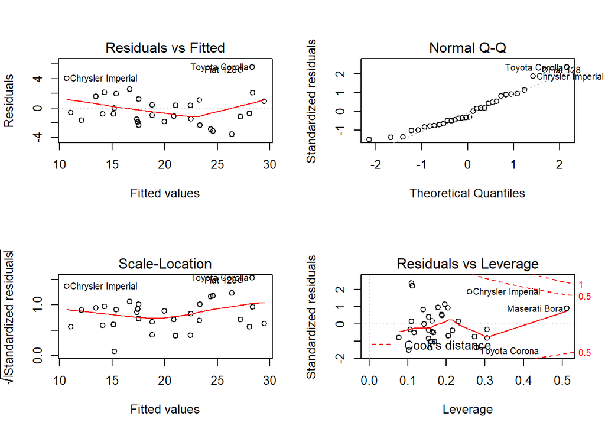

```r
par(mfrow=c(2,2))
plot(MLRadjusted)
```

The first, “Residuals vs Fitted” plot supports that the null rejection was accurate and the groups are independent. The “Normal Q-Q” plot appears to support a normal distribution since the residuals are close to the fit line. The “Scale Location” plot is in line with the assumption of constant variance sine the points are randomly distributed. Finally, the “Residuals vs Leverage” shows there are no identified outliers.

# In Conclusion

The final multivariate linear regression model, which included the highly correlated variables (wt, hp, disp, and cyl are confounding variables for ‘am’ and ’mpg) showing a value for R^2 of 0.83, meaning that 83% of the regression variance can be explained by the variables included in the model. It can also be seen from this model that manual transmissions (on average) have 1.55 miles per gallon more than that of an automatic.